# Project 1

**Model Modification**

```r
modelP5 <- lm(housing$price ~ housing$size + housing$garagesize + housing$bedrooms)
summary(modelP5)
```

```
##
## Call:
## lm(formula = housing$price ~ housing$size + housing$garagesize +
##     housing$bedrooms)
##
## Residuals:
##      Min       1Q   Median       3Q      Max
## -116.396  -42.045   -8.027   39.502  162.858
##
## Coefficients:
##                    Estimate Std. Error t value Pr(>|t|)
## (Intercept)         204.859     62.747   3.265  0.00168 **
## housing$size         63.515     32.449   1.957  0.05418 .
## housing$garagesize   17.053      9.481   1.799  0.07627 .
## housing$bedrooms    -20.570     10.062  -2.044  0.04458 *
## ---
## Signif. codes:  0 '***' 0.001 '**' 0.01 '*' 0.05 '.' 0.1 ' ' 1
##
## Residual standard error: 55.24 on 72 degrees of freedom
## Multiple R-squared:  0.1952, Adjusted R-squared:  0.1616
## F-statistic:  5.82 on 3 and 72 DF,  p-value: 0.001282
```

```r
modelP6 <- lm(housing$price ~ housing$size + housing$bedrooms)
summary(modelP6)
```

```
##
## Call:
## lm(formula = housing$price ~ housing$size + housing$bedrooms)
##
## Residuals:
##      Min       1Q   Median       3Q      Max
## -115.266  -42.749   -6.262   40.138  173.437
##
## Coefficients:
##                  Estimate Std. Error t value Pr(>|t|)
## (Intercept)       225.717     62.603   3.606 0.000566 ***
## housing$size       81.215     31.391   2.587 0.011666 *
## housing$bedrooms  -28.992      9.042  -3.206 0.001995 **
## ---
## Signif. codes:  0 '***' 0.001 '**' 0.01 '*' 0.05 '.' 0.1 ' ' 1
##
## Residual standard error: 56.08 on 73 degrees of freedom
## Multiple R-squared:  0.159,  Adjusted R-squared:  0.136
## F-statistic: 6.902 on 2 and 73 DF,  p-value: 0.001797
```

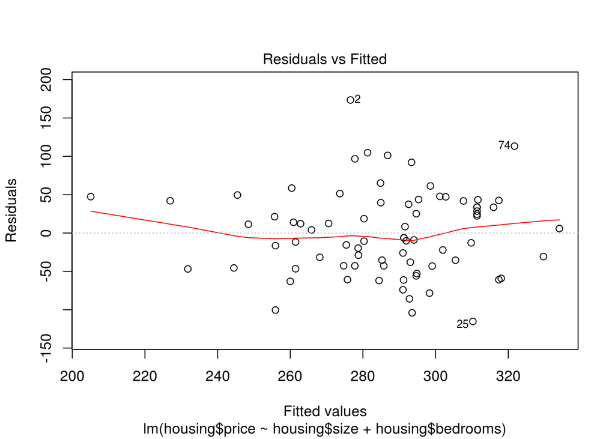

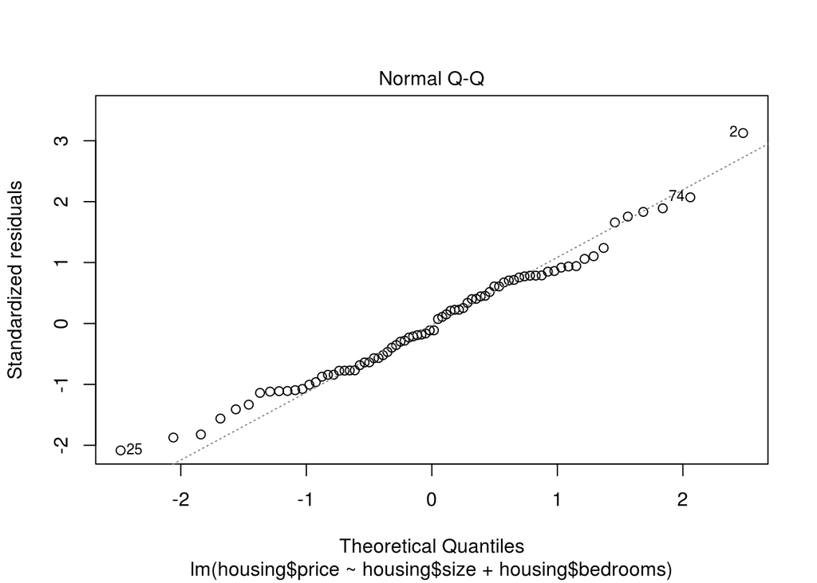

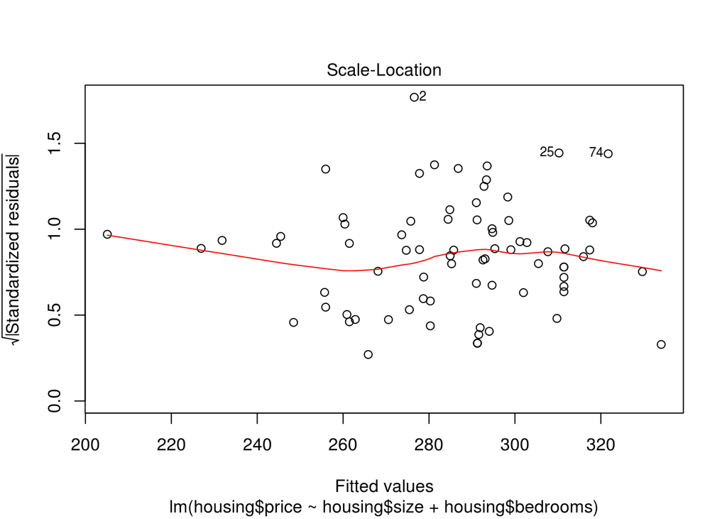

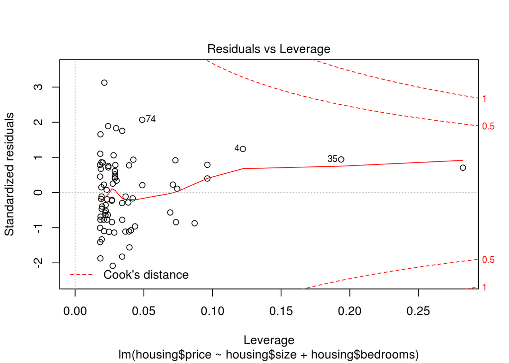

```r
plot(modelP6)
```

I started with the inital model (modelP4) that I made and saw that the predictor lot had the highest p-value and the smallest intercept value so I took it out of the model and noticed all the other predictors p-values dropped and the intercept p-value dropped. I did the same process again just with the garagesize predictor and once again the p-values dropped. I was then left with size and bedroooms as my two predictors both havin p-values less that 0.12 and my F-statistic went up. The R^2 value did get lower through this process due to taking out predictors but the final model still represents about 16% of the variation in the data set.

The plots for this final model (modelP6) look similar to the ones for the initial model (modelP4). The final model Residuals vs Leverage plot does level off more than the initial models which is great. However, it did not seem to completely fix the QQ Plot deviation on the left side. It does seem to have made it marginally better by it coming back toward the straight line after veering off a little.

```r
library(Rmisc)
CI(housing$size, ci = 0.95)
```

```
##    upper     mean    lower
## 2.018935 1.970395 1.921855
```

```r
CI(housing$bedrooms, ci = 0.95)
```

```
##    upper     mean    lower
## 3.615887 3.447368 3.278850
```